# Del catastro habilitado al catastro que financia el desarrollo

Capacidades en gestión catastral y capacidad fiscal subnacional

Juan Carlos Muñoz-Mora, PhD

Centro de Valor Público · Escuela de Finanzas, Economía y Gobierno

11 de septiembre de 2026

## El Área Metropolitana administra el catastro de cuatro municipios desde 2020

2019Resolución IGAC 1267: habilitación como gestor catastral

4municipios: Bucaramanga, Floridablanca, Girón y Piedecuesta

326municipios del país con catastro multipropósito, de 1.104

0,7 %del PIB recauda Colombia en predial; la OCDE cerca de 1,4 %

La pregunta de esta sesión no es si vale la pena tener catastro propio: eso ya está resuelto aquí. Es **cómo se convierte un catastro habilitado en financiación estable del desarrollo metropolitano** — y por qué buena parte de la respuesta no está en el avalúo.

IGAC, Resolución 1267 del 10 de octubre de 2019 · IGAC, febrero de 2026 · OCDE, estadísticas de ingresos tributarios.

Parte 1

El punto de partida

Qué se construyó, qué está pasando en el entorno y dónde se abre la ventana.

## Siete años de gestión catastral metropolitana

Año

El Área Metropolitana

El entorno nacional y regional

2019

El IGAC habilita al AMB como gestor catastral de los cuatro municipios.

Se adopta la actualización catastral adelantada por el IGAC en el área urbana.

2020

El 7 de enero inicia la prestación del servicio, con dos meses de empalme.

El Tribunal Administrativo de Santander suspende la actualización sobre el 40 % de los predios.

2022

40.630 predios conservados · 14.573 incorporados · 18.590 trámites atendidos.

La política nacional de catastro multipropósito acelera: 36 gestores habilitados en el país.

2024-25

Cartografía automática, estratificación con empresas de servicios públicos e integración con el acueducto metropolitano.

El Consejo de Estado revoca la suspensión y la actualización queda en firme.

2026

Resolución 343 de 2025: reliquidación de oficio de avalúos para la vigencia 2026 en zonas identificadas.

La Resolución IGAC 2057 de 2025 reajusta avalúos rurales en 527 municipios desde el 1 de enero; la Resolución 384 habilita modular los incrementos.

IGAC (2019, 2022, 2025, 2026) · La República, especial *Santander corazón de Colombia* · Comunicado oficial de la Alcaldía de Piedecuesta, 15 de abril de 2026.

## Sobre una base ya construida

40.630predios conservados en 2022

14.573predios nuevos incorporados

18.590trámites atendidos

9.691ciudadanos atendidos

Capacidad técnica instalada

- Generación automática de cartografía con redes neuronales
- Estratificación socioeconómica estandarizada con las empresas de servicios públicos
- Integración de uso del suelo con la Cámara de Comercio
- Memorando con el acueducto metropolitano para incorporar servicios públicos al catastro

Muy pocos territorios del país tienen esto: **un operador supramunicipal con datos prediales propios, series de trámites y cruces con servicios públicos**. Es la infraestructura sobre la que se construye todo lo demás.

La República, especial *Santander corazón de Colombia* (cifras de gestión 2022) · Área Metropolitana de Bucaramanga, comunicaciones institucionales.

## La ventana de decisión está abierta ahora

Resolución 343 de 2025 Reliquidación de oficio Actuación administrativa sobre zonas identificadas para la vigencia 2026, sin necesidad de solicitud ciudadana.

Resolución IGAC 384 de 2026 Margen para modular Faculta ajustar por acto administrativo los porcentajes de incremento catastral de la vigencia 2026.

Acuerdos de abril de 2026 Tarifas sobre la mesa Convenio para fortalecer capacidad operativa y revisión de tarifas y descuentos por pronto pago con los municipios.

Las tres decisiones convergen en un mismo momento y sobre un mismo objeto: **el avalúo se está ajustando y la tarifa se está discutiendo, al mismo tiempo**. Es exactamente la ventana en la que un rediseño tarifario cambia el resultado — y se cierra con la vigencia.

Área Metropolitana de Bucaramanga, Resolución 343 de 2025 · IGAC, Resolución 384 del 9 de abril de 2026, que adiciona el parágrafo 3.º del artículo 2.º de la Resolución 2057 de 2025 · Comunicado oficial de la Alcaldía de Piedecuesta, 15 de abril de 2026.

## El esfuerzo predial es alto; la dependencia de transferencias también

| Municipio | Predial per cápita 2024 | Percentil nacional | Dependencia de transferencias | Desempeño fiscal |
| --- | --- | --- | --- | --- |
| Bucaramanga | $ 460.000 | 97,5 | 46,5 % | 62,9 |
| Floridablanca | $ 360.000 | 95,8 | 55,2 % | 60,9 |
| Piedecuesta | $ 260.000 | 92,6 | 64,7 % | 60,0 |
| Girón | $ 130.000 | 78,7 | 61,5 % | 64,8 |

Los cuatro municipios superan el **percentil 78** nacional en recaudo predial por habitante. Tres superan el 92. El esfuerzo fiscal no es el problema.

Bucaramanga recauda **3,5 veces** más predial por habitante que Girón, sobre un mismo territorio funcional y un mismo gestor catastral. La diferencia la explica la estructura tarifaria, no el avalúo.

DNP — TerriData, Dimensión de Finanzas Públicas, consulta del 11 de septiembre de 2026. Percentiles calculados entre los municipios que reportan cada indicador en 2024. Cálculo reproducible en `03_datos/panel_amb.py`.

Parte 2

El dilema de toda modernización catastral

Mejor dato produce mayor choque fiscal. Qué variable decide si la reforma sobrevive.

## El avalúo se actualiza; la tarifa decide el resultado

Avalúo actualizado · tarifa intacta

1. El avalúo se acerca al valor comercial.
2. El predio **sube de escalón tarifario** sin que nadie lo decida.
3. La factura salta por encima del ingreso del hogar.
4. Litigio, suspensión, protesta.
5. La reforma se revierte.

Avalúo actualizado · tarifa recalibrada

1. El avalúo se actualiza igual.
2. **El estatuto se rediseña en el mismo acto**, con topes legales por predio.
3. La factura mediana se mueve poco; la carga residencial puede bajar.
4. La progresividad queda demostrada y es defendible.
5. La reforma sobrevive y financia la operación.

El catastro actualizado es la condición **necesaria**. El estatuto rediseñado es la condición **suficiente**.

Marco analítico del artículo sobre modernización catastral y diseño tarifario del Centro de Valor Público, sometido a revisión por pares en 2026.

+89 %

creció la base gravable de 88 municipios de Antioquia entre 2025 y 2026, de 57,2 a 108,1 billones de pesos.

El choque no se evita con menos catastro. Se administra con mejor estatuto.

Parte 3

Cuatro capacidades

Medir la capacidad · rediseñar el estatuto · financiar la operación · operar todos los días.

## Capacidad 1 · Medición censal de capacidad catastral

Gobernación de Antioquia · Planeación, Hacienda y Gerencia de Catastro Estado de la gestión catastral en Antioquia, 2025 1.105 millones de pesos · 11 investigadores · junio a diciembre de 2025 · encuesta censal en 10 módulos, campo entre julio y septiembre de 2025.

125/125municipios respondieron: cobertura censal, no muestral

39,7 %de las oficinas de catastro opera con **una sola persona**

80,4 %no tiene vehículo para trabajo de campo

95,5 %no tiene equipo topográfico; 78,6 % no tiene GPS

La economía de escala de un gestor supramunicipal no está en comprar plataforma entre varios: está en **sostener un equipo técnico que ningún municipio sostiene solo**. Eso se financia de forma permanente, no por proyecto.

Encuesta diagnóstico de gestión catastral, Antioquia 2025 (n = 125 municipios). Centro de Valor Público, Universidad EAFIT, y Gobernación de Antioquia.

## Quien fija el avalúo necesita observar su propio mercado

91,2 %de los municipios no tiene ninguna injerencia en el avalúo de su territorio

71,7 %considera que el avalúo no refleja su mercado inmobiliario

71,7 %no hace seguimiento a la dinámica inmobiliaria local

15,7 %tiene consulta catastral en línea para el ciudadano

Cuando llega el reclamo, el municipio **no tiene con qué defender la cifra**: ni serie de precios, ni estudio de oferta, ni evidencia local. La única respuesta disponible es administrativa.

Para un gestor habilitado la conclusión se invierte: el **observatorio inmobiliario propio** no es un lujo analítico, es el respaldo técnico de cada notificación y la primera línea de defensa ante el juez.

Encuesta diagnóstico de gestión catastral, Antioquia 2025 · Resolución IGAC 746 de 2024, artículo 5.4.1: el avalúo no puede ser inferior al 60 % del valor comercial.

## Capacidad 2 · Rediseño del estatuto tributario

Gobernación de Antioquia · protocolo oficial de asistencia técnica en diseño tarifario Optimización de tarifas del impuesto predial bajo restricciones legales Programación lineal con piso de recaudo, techos legales por uso, progresividad mínima entre escalones y topes de crecimiento predio a predio. Artículo sometido a revisión por pares, 2026.

88municipios

929.703predios analizados

5.283reglas tarifarias inventariadas

3,2 %desviación mediana del modelo frente a la facturación real de 81 municipios

No es una simulación: el modelo está **calibrado contra liquidaciones administrativas efectivas**, y su salida es el articulado del acuerdo, no un informe.

88 municipios de Antioquia · 17 provincias. Centro de Valor Público, Universidad EAFIT (2026).

## La progresividad declarada no es la progresividad efectiva

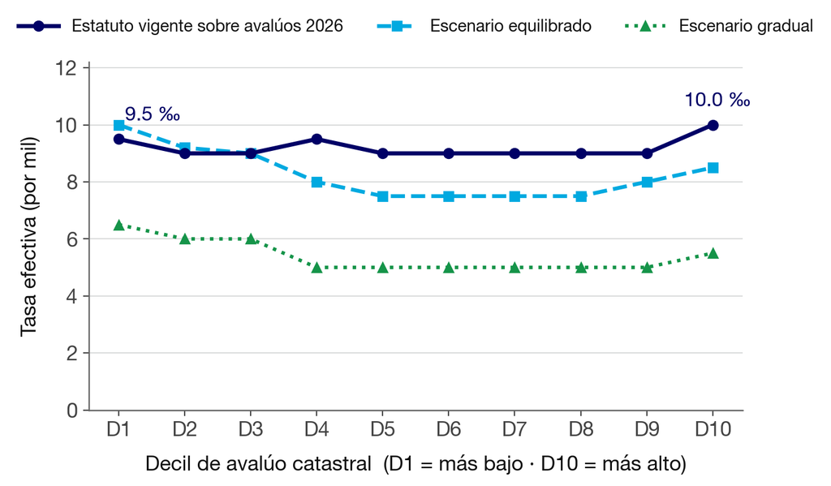

9,5 ‰ · 10,0 ‰tasa efectiva en el decil más bajo frente al más alto: un impuesto plano de facto

50combinaciones tarifarias tiene el municipio mediano; el máximo observado es 182

55 / 88municipios con estatuto anterior a 2022

Tasa efectiva calculada sobre avalúos 2026 con el estatuto vigente. Inventario de estatutos tributarios municipales de Antioquia (2025–2026), con verificación manual del 100 % de los casos señalados y del 20 % de una muestra aleatoria.

## No hay que elegir entre proteger al contribuyente y financiar al municipio

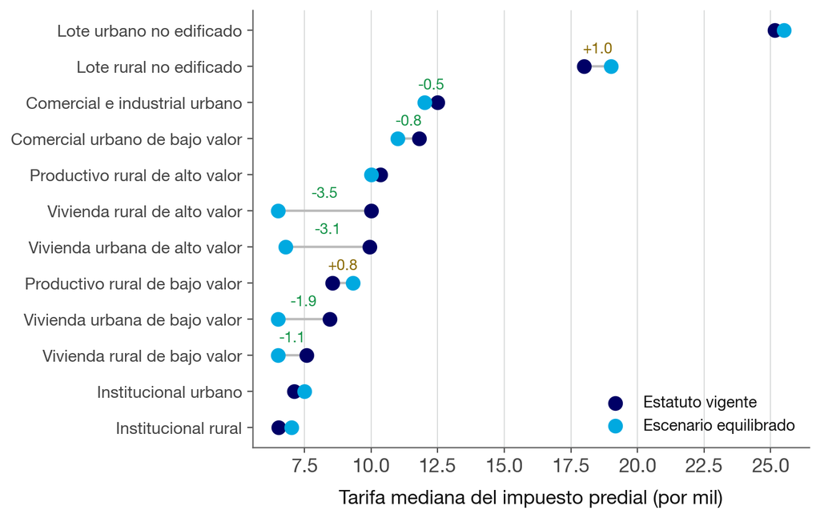

+7,7 %puede aumentar la liquidación el municipio mediano **mientras reduce** la carga sobre la vivienda

9,9 → 6,8 ‰cae la tarifa mediana de vivienda urbana de alto valor; el lote no edificado sube

90 %de los municipios tiene como restricción activa el piso de recaudo que **él mismo se impone**, no el tope legal

Escenarios de optimización sobre 88 municipios y 929.703 predios. Restricciones: piso legal de 5 por mil (Ley 44 de 1990), techos por uso, progresividad mínima entre escalones y topes de crecimiento por predio.

## El resultado se ve en el mapa, y termina en un acuerdo municipal

Tarifa habitacional · antes

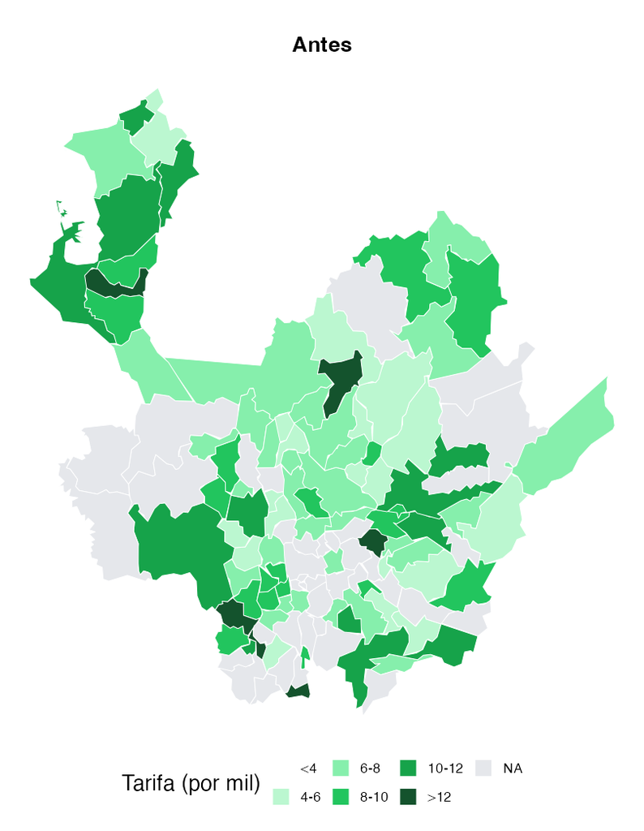

Tarifa habitacional · después

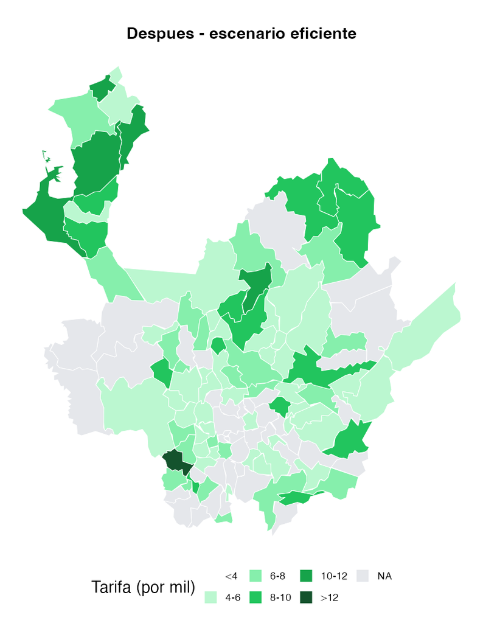

88municipios con análisis y **proyecto de acuerdo listo para radicar**

15adoptaron plenamente la estructura optimizada para 2026

60 → 8reglas por sector tras la simplificación, en unidad única UVT

Mapas de tarifa habitacional antes y después del rediseño, 88 municipios de Antioquia. Progresividad garantizada en el 100 % de los estatutos rediseñados.

## La actualización explica la mitad del recaudo predial a diez años

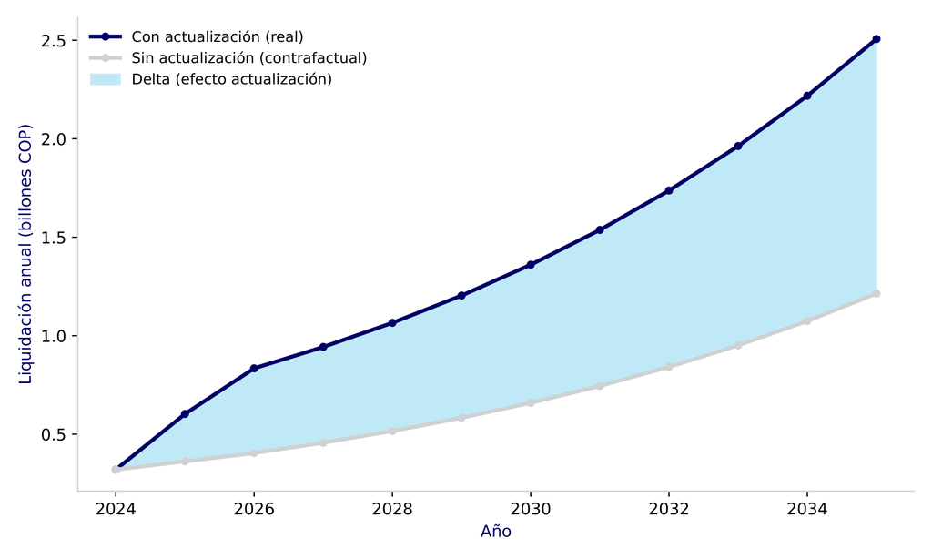

51 %del recaudo proyectado a diez años no existiría sin la actualización: 6,07 billones de pesos en valor presente

42–54 %es el peso del efecto en áreas metropolitanas, menor porque su base ya es dinámica

54–64 %del efecto es efectivamente cobrable: el resto es gestión de cartera

Horizonte 2025–2035, crecimiento vegetativo del 13 % anual y descuento del 5 %. Valor presente con actualización: 11,91 billones; contrafactual sin actualizar: 5,84 billones. Tasa efectiva de recaudo estimada con series CUIPO y FUT 2017–2024. Las cifras son de liquidación potencial.

## Capacidad 3 · Habilitación y sostenibilidad de esquemas asociativos

Gobernación de Antioquia · Departamento Administrativo de Planeación · contrato 4600019013 Estudio de habilitación catastral e impacto fiscal de 14 esquemas asociativos Modelo de cinco factores ponderados sobre la Resolución IGAC 1040 de 2023 y su modificatoria 746 de 2024. En ejecución durante 2026.

14esquemas evaluados, que agrupan 100 municipios

11.034trámites de conservación al año: la carga operativa real

$ 208.152 Mcosto estimado de la gestión catastral en los 14 esquemas

+98 a +488 %rango de crecimiento del avalúo entre provincias

Precedente directo para un área metropolitana: el **Área Metropolitana de Barranquilla** fue habilitada en 2024 como el primer esquema asociativo gestor catastral del país.

Resolución IGAC 1040 de 2023, Título III, capítulos 1 y 2; Resolución IGAC 746 de 2024. Factores: municipios faltantes 35 %, cercanía al índice de desempeño fiscal 25 %, medición de desempeño municipal 15 %, estado de actualización 15 %, carga de conservación 10 %.

## El catastro supramunicipal puede pagarse con el recaudo que produce

El mecanismo

El esquema capta una fracción del **incremento de recaudo atribuible a la actualización** —no del recaudo total— y con ella financia la operación permanente: equipo, plataforma y campo.

Diseño propuesto: **10 %** del delta de recaudo predial de los municipios más **10 %** del impuesto de registro del departamento.

$ 98.000 Mflujo anual del fondo

$ 85.000 Mcosto anual de la gestión catastral

8,4 % – 117 %capacidad de autofinanciarse según el territorio

Sin mecanismo solidario, las zonas de base gravable baja nunca pagan su propio catastro. Con una diferencia de **3,5 veces** en recaudo per cápita entre municipios de una misma área metropolitana, eso es una **decisión de diseño**, no un detalle contable.

Modelo de fondo de incentivos para la gestión catastral, proyecto de esquemas asociativos territoriales, Gobernación de Antioquia (2026). Cifras en pesos corrientes.

## Y se mide con reglas que solo puntúan lo demostrable

ICAP · índice de capacidades ¿Tiene con qué ejercer lo que quiere ejercer? Cinco dimensiones de igual peso, sobre el marco de cooperación intermunicipal de Feiock (2013).

ICOP · índice de competencias ¿Qué competencias ejerce efectivamente hoy? Ocho dimensiones, sobre el *Regional Authority Index* adaptado a la Ley 1454 de 2011 y al Decreto 1033 de 2021.

**Solo puntúa lo que existe como documento** —ordenanza, convenio, estatutos, registro, acto de delegación—. La voluntad política vale cero puntos. Eso convierte el diagnóstico en una línea de base defendible ante un ente de control, y responde una pregunta concreta: qué conviene centralizar y qué debe quedarse en el municipio.

Feiock, R. (2013) · Hooghe, Marks y Schakel, *Regional Authority Index*, adaptado a la Ley 1454 de 2011 (Ley Orgánica de Ordenamiento Territorial) y al Decreto 1033 de 2021.

## Capacidad 4 · La implementación existe y está verificada

[interactive chart not shown]

MuniGest es el modelo científico desarrollado en EAFIT; Kyverum es la plataforma del aliado tecnológico Inteligente S.A.S. Proyecto de alistamiento tecnológico EAFIT 2026–2027, en ejecución, con pilotos en Guarne, La Dorada y Envigado.

## Construido con quienes ya son gestores catastrales

Envigado · gestor habilitado desde 2021 Interoperabilidad, no reemplazo Gestor número 21 del país (Resolución IGAC 95 de 2021), con sistema propio en operación. El piloto produce un documento técnico de interoperabilidad entre ese sistema y la plataforma.

Distrito de Medellín · Subsecretaría de Catastro Analítica sobre 1.075.910 predios Entre 2014 y 2023 los predios crecieron 16,1 % y la base gravable 184,1 %, de 69,8 a 198,2 billones. Propuesta técnica en curso sobre reconciliación de fuentes y auditoría de equidad.

Ninguno de los dos necesitaba ser convencido de nada. Son gestores en operación con problemas de gestor en operación: **oportunidad del trámite, interoperabilidad y defensa técnica del avalúo**. Es la misma conversación que cabe tener aquí.

Resolución IGAC 95 de 2021 · Plan de Desarrollo Distrital de Medellín 2024–2027, tabla 43 · Centro de Valor Público, Universidad EAFIT (2026).

## La alternativa a actualizar cada cinco años es verificar de forma continua

Nueve fuentes que el territorio ya produce

Base catastral · predial · registro de instrumentos públicos · curadurías · acometidas de servicios públicos · cámara de comercio · fotografía aérea · oferta inmobiliaria · campo.

El terreno deja de ser censal y pasa a ser dirigido: se visita donde la discrepancia entre fuentes es grande y el impacto fiscal esperado lo justifica.

**Recaudo = cobertura × valoración × tarifa × cumplimiento.** Las cuatro se miden por separado; solo una es el avalúo.

Equidad auditada con estándar internacional

0,90–1,10nivel de valoración admisible

5,0–15,0coeficiente de dispersión residencial

± 10 %diferencial vertical entre predios de alto y bajo valor

Como indicador **contractual**, son el blindaje político de la actualización: permiten demostrar, predio a predio, dónde quedó la carga.

International Association of Assessing Officers, *Standard on Ratio Studies* (2025). Marco de reconciliación de fuentes desarrollado por el Centro de Valor Público para catastros urbanos de alta densidad (2026).

Parte 4

Lo que seguiría

Tres preguntas que se responden con datos que el Área Metropolitana ya tiene.

## Tres preguntas, tres productos

01 · Capacidad ¿Con qué se opera hoy? Instrumento censal aplicado a la subdirección de catastro y a las cuatro secretarías de hacienda. Producto: línea de base defendible ante control.

02 · Brecha ¿Cuánto se deja sobre la mesa? Inventario de los cuatro estatutos sobre la base catastral y la serie de recaudo. Producto: separación entre problema de tarifa y problema de cartera.

03 · Arquitectura ¿Qué se centraliza? Índices de capacidad y competencias más modelo de financiación permanente. Producto: reparto de competencias entre el área y sus municipios.

Ninguna requiere un dato que el Área Metropolitana no tenga. Requieren ordenarlos con un método probado en **125 municipios, 88 estatutos y 929.703 predios**.

La secuencia natural es capacidad → brecha → arquitectura: cada ejercicio alimenta al siguiente.

Para cerrar

El catastro no es un trámite: es la reforma que financia las demás

El avalúo actualizado es la condición necesaria. La tarifa recalibrada es la suficiente. Y la ventana de esta vigencia está abierta.

**Juan Carlos Muñoz-Mora, PhD** · jmunozm1@eafit.edu.co  
Centro de Valor Público · Escuela de Finanzas, Economía y Gobierno · Universidad EAFIT

**Uso de inteligencia artificial.** La estructura narrativa y el borrador de esta presentación fueron asistidos por IA, y la visualización de arquitectura se programó con asistencia de IA a partir del expediente técnico del proyecto. Los datos, su verificación contra fuente y la curaduría del argumento son del autor. Ninguna cifra proyectada fue generada por IA.